# Assignment 4

Hannah Irish, Nadine Snyder, Zoe Rennie

2023-05-02

#### Use LHS hypercube to generate parameter values for k_o, k_d, v, and height:

```r
source(here("R", "Catm.R"))
# set a random seed to make things 'random'
set.seed(1)
# which parameters
pnames = c("v", "height", "k_o", "k_d")
# how many parameters
npar =  length(pnames)
# how many samples
nsample = 100
#randomize samples
parm_quant = randomLHS(nsample, npar)
#set column names
colnames(parm_quant)=pnames
#create LHS matrix for sampling from distributions
parm = as.data.frame(matrix(nrow=nrow(parm_quant), ncol=ncol(parm_quant)))
colnames(parm) = pnames
pvar = 10
#sample distributions
parm[,"v"] = qnorm(parm_quant[,"v"], mean=.25, sd=.03)
parm[,"height"] = qunif(parm_quant[,"height"], min=9.5, max=10.5)
parm[,"k_o"] = qnorm(parm_quant[,"k_o"], mean=.1, sd=.1*.01)
parm[,"k_d"] = qnorm(parm_quant[,"k_d"], mean=.7, sd=.7*.01)
#check samples
head(parm)
```

```
##           v    height        k_o       k_d
## 1 0.2313051  9.651851 0.10087622 0.7003331
## 2 0.2476994  9.827237 0.09939835 0.6905195
## 3 0.2902433 10.169403 0.10103617 0.7029557
## 4 0.2111180 10.077929 0.10222797 0.6972034
## 5 0.2533871  9.813081 0.10054450 0.7013815
## 6 0.2643967 10.425147 0.10043063 0.6930799
```

#### Run model with for these parameters:

```r
#run samples with model
conductance <- parm %>% pmap(Catm)
head(conductance, n=10)
```

```
## [[1]]
## [1] 1.298143
##
## [[2]]
## [1] 1.391463
##
## [[3]]
## [1] 1.661861
##
## [[4]]
## [1] 1.209972
##
## [[5]]
## [1] 1.429068
##
## [[6]]
## [1] 1.524201
##
## [[7]]
## [1] 1.431197
##
## [[8]]
## [1] 1.357676
##
## [[9]]
## [1] 1.640116
##
## [[10]]
## [1] 1.276574
```

#### Plotting the conductance estimates to account for uncertainty:

```r
##convert conductance list to data frame
conductance_df <- data.frame(conductance)
##make tidy and select desired column
conductance_tidy <- conductance_df %>%
  pivot_longer(cols=(1:ncol(conductance_df)), names_to = "junk_col", values_to = "conductance") %>%
  select(2)
##combine with parm data frame to plot appropriately
plot_df <- cbind(conductance_tidy, parm)
```

## **Estimates for Conductance Showing Variation in Parameters**

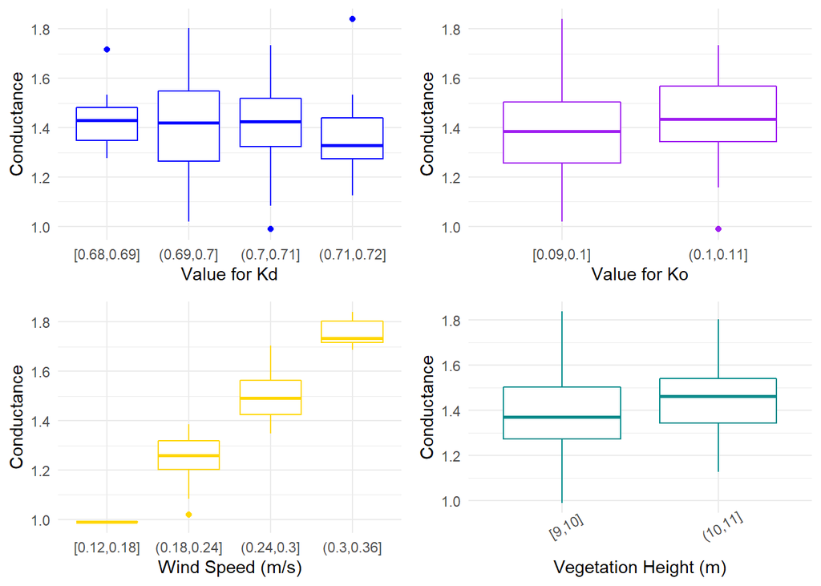

```r
##setting up box plots for each variable to show uncertainty
k_d_boxplot <- ggplot(plot_df, aes(x = cut_interval(x=k_d, length=.01), y = conductance)) +
  geom_boxplot(color = "blue") +
  labs(x= "Value for Kd", y="Conductance", color="Conductance")+
  theme_minimal()

k_o_boxplot <- ggplot(plot_df, aes(x = cut_interval(x=k_o, length=.01), y = conductance)) +
  geom_boxplot(color = "purple") +
  labs(x= "Value for Ko",y="Conductance", color="Conductance")+
  theme_minimal()

v_boxplot <- ggplot(plot_df, aes(x = cut_interval(x=v, length=.06), y = conductance)) +
  geom_boxplot(color = "gold") +
  labs(x= "Wind Speed (m/s)", y="Conductance", color="Conductance")+
  theme_minimal()

height_boxplot <- ggplot(plot_df, aes(x = cut_interval(x=height, length=1), y = conductance)) +
  geom_boxplot(color = "cyan4") +
  labs(x= "Vegetation Height (m)", y="Conductance", color="Conductance")+
  theme_minimal() + theme(axis.text.x = element_text(angle = 30))


title <- ggdraw() + draw_label("Estimates for Conductance Showing Variation in Each Variable", fontface='bold')

##plot all 4 boxplots together


cowplot::plot_grid(k_d_boxplot, k_o_boxplot, v_boxplot, height_boxplot)
```

#### Plotting the conductance estimates against each parameter:

## **Estimates for Conductance vs. Range of Each Parameter**

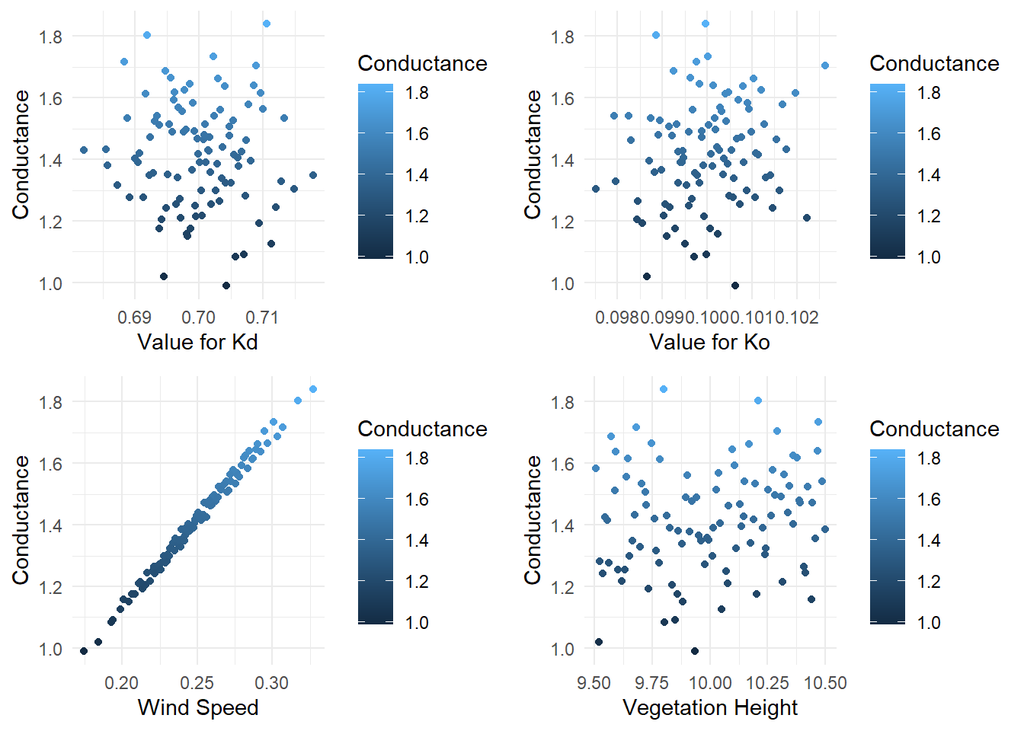

```r
##setting up plots that show every variable against conductance
k_d_plot <- ggplot(plot_df, aes(x = k_d, y = conductance)) +
  geom_point(aes(color = conductance)) +
  scale_color_gradient() +
  labs(x= "Value for Kd", y="Conductance", color="Conductance")+
  theme_minimal()
k_o_plot <- ggplot(plot_df, aes(x = k_o, y = conductance)) +
  geom_point(aes(color = conductance)) +
  scale_color_gradient() +
  labs(x= "Value for Ko",y="Conductance", color="Conductance")+
  theme_minimal()
v_plot <- ggplot(plot_df, aes(x = v, y = conductance)) +
  geom_point(aes(color = conductance)) +
  scale_color_gradient() +
  labs(x= "Wind Speed", y="Conductance", color="Conductance")+
  theme_minimal()
height_plot <- ggplot(plot_df, aes(x = height, y = conductance)) +
  geom_point(aes(color = conductance)) +
  scale_color_gradient() +
  labs(x= "Vegetation Height", y="Conductance", color="Conductance")+
  theme_minimal()
##Plot all 4 variable plots against one another
cowplot::plot_grid(k_d_plot, k_o_plot, v_plot, height_plot)
```

### Partial Rank Correlation Coefficients

```r
# Combine Parameter sets with outputs
senresult = pcc(parm, conductance_tidy)
# see coefficients
senresult
```

```
##
## Call:
## pcc(X = parm, y = conductance_tidy)
##
## Partial Correlation Coefficients (PCC):
##         original
## v      0.9999300
## height 0.9916891
## k_o    0.9372664
## k_d    0.1638221
```

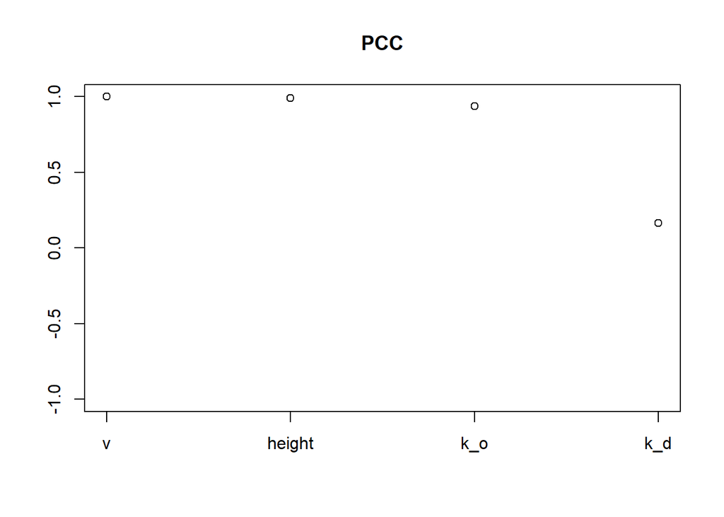

```r
# plot
plot(senresult)
```

```r
#rank coefficients
senresult_rank = pcc(parm, conductance_tidy, rank=TRUE )
senresult_rank
```

```
##
## Call:
## pcc(X = parm, y = conductance_tidy, rank = TRUE)
##
## Partial Rank Correlation Coefficients (PRCC):
##          original
## v       0.9988798
## height  0.8657835
## k_o     0.4100546
## k_d    -0.1835439
```

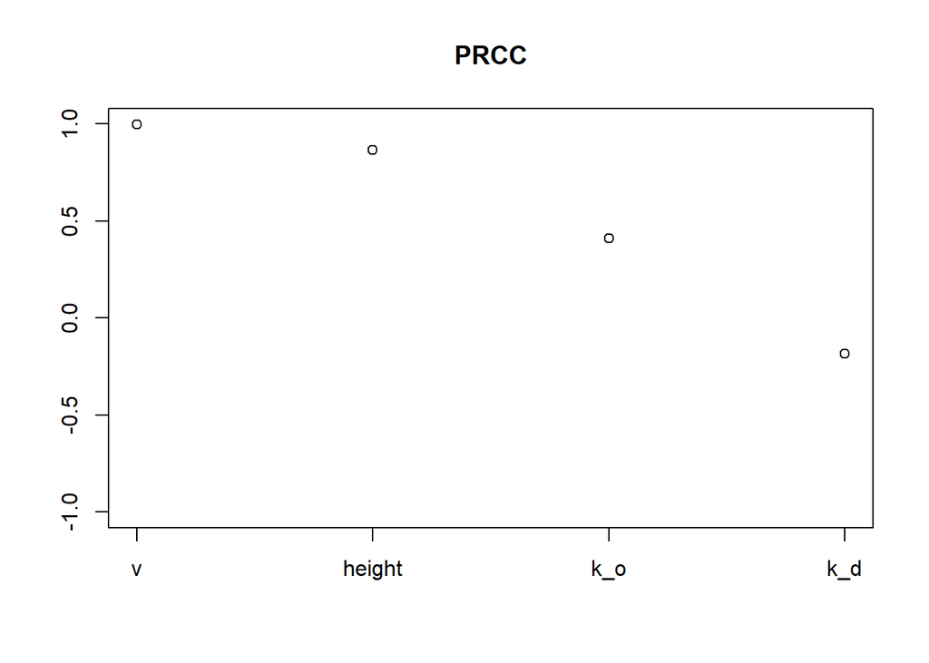

```r
plot(senresult_rank)
```

```r
str(senresult)
```

```
## List of 7
##  $ X    :'data.frame':   100 obs. of  4 variables:
##   ..$ v     : num [1:100] 0.231 0.248 0.29 0.211 0.253 ...
##   ..$ height: num [1:100] 9.65 9.83 10.17 10.08 9.81 ...
##   ..$ k_o   : num [1:100] 0.1009 0.0994 0.101 0.1022 0.1005 ...
##   ..$ k_d   : num [1:100] 0.7 0.691 0.703 0.697 0.701 ...
##  $ y    : tibble [100 × 1] (S3: tbl_df/tbl/data.frame)
##   ..$ conductance: num [1:100] 1.3 1.39 1.66 1.21 1.43 ...
##  $ rank : logi FALSE
##  $ nboot: num 0
##  $ conf : num 0.95
##  $ call : language pcc(X = parm, y = conductance_tidy)
##  $ PCC  :'data.frame':   4 obs. of  1 variable:
##   ..$ original: num [1:4] 1 0.992 0.937 0.164
##  - attr(*, "class")= chr "pcc"
```

```r
senresult$PCC
```

```
##         original
## v      0.9999300
## height 0.9916891
## k_o    0.9372664
## k_d    0.1638221
```

#### Discussion

Discuss what your results tell you about how aerodynamic conductance? What does it suggest about what you should focus on if you want to reduce uncertainty in aerodynamic conductance estimates? Does this tell you anything about the sensitivity of plant water use to climate change?

Our results show that aerodynamic conductance is most greatly impacted by wind speeds. This is demonstrated by the linear relationship between wind speeds and conductance. Therefore in order to reduce uncertainty in aerodynamic conductance estimates, one should focus on testing conductance amongst a range of wind speeds, or measure conductance in a place with stable wind speeds. This tells us that plant water usage is extremely sensitive to climate change. This is because as the climate changes, wind patterns will change as well, greatly influencing atmospheric conductance. This will change the amount of water available to plants, and could harm them, especially if they evolved to live under specific conditions.